# TEI Corpus Summary

Fan Du

5/30/2020

- 4,971 articles, 2,300 paragraphs, and 1,078 non-matched quotes
- 3,544 articles with zero mentions, and 1,427 articles with one or more software mentions
  - Among 1,427 articles with mentions, 1,240 have annotated paragraphs matched with PDF; 483 articles have non-matched quotes; 297 have both matched annotations and non-matched quotes.
  - All the 1,240 articles with annotated paragraphs are reviewed by curators during the consistency improvement.
- 2,521 PMC articles and 2,450 econ articles
- 4,400 articles are annotated once. 571 articles are annotated by multiple annotators.
- 1,242 articles are reviewed by curators and passed the scripted consistency check.
- 5,169 software entities and 3,166 software attributes annotated. 8,335 annotations in total.
- 1,171 annotations manually edited during the consistency check

**1. Manually edited annotations during consistency check:**

| edited_during_review | n | percent |
| --- | --- | --- |
| FALSE | 7164 | 86.0% |
| TRUE | 1171 | 14.0% |
| Total | 8335 | 100.0% |

**2. If the mentioned software was used:**

| software_was_used | econ_article | pmc_article | Total |
| --- | --- | --- | --- |
| not_used | 41.0% (270) | 16.4% (742) | 19.6% (1012) |
| used | 59.0% (388) | 83.6% (3769) | 80.4% (4157) |
| Total | 100.0% (658) | 100.0% (4511) | 100.0% (5169) |

[figure not shown]

**3: How was software mentioned?**

Note: The Venn diagram is not ideal because software mentioned with more than two attributes are very rare. Tried several ways and this is the best I can get so far. I think the issue is inherent in the data (but the data is ground truth so software is really rarely mentioned with additional information.) The relative size of diferent sets is referable but the overlapping between sets do not reflect patterns in the data.

| type | econ_article | pmc_article | Total |
| --- | --- | --- | --- |
| publisher | 21.0% (286) | 15.3% (1069) | 16.3% (1355) |
| software | 48.2% (658) | 64.7% (4511) | 62.0% (5169) |
| url | 4.2% (57) | 2.2% (156) | 2.6% (213) |
| version | 26.7% (364) | 17.7% (1234) | 19.2% (1598) |
| Total | 100.0% (1365) | 100.0% (6970) | 100.0% (8335) |

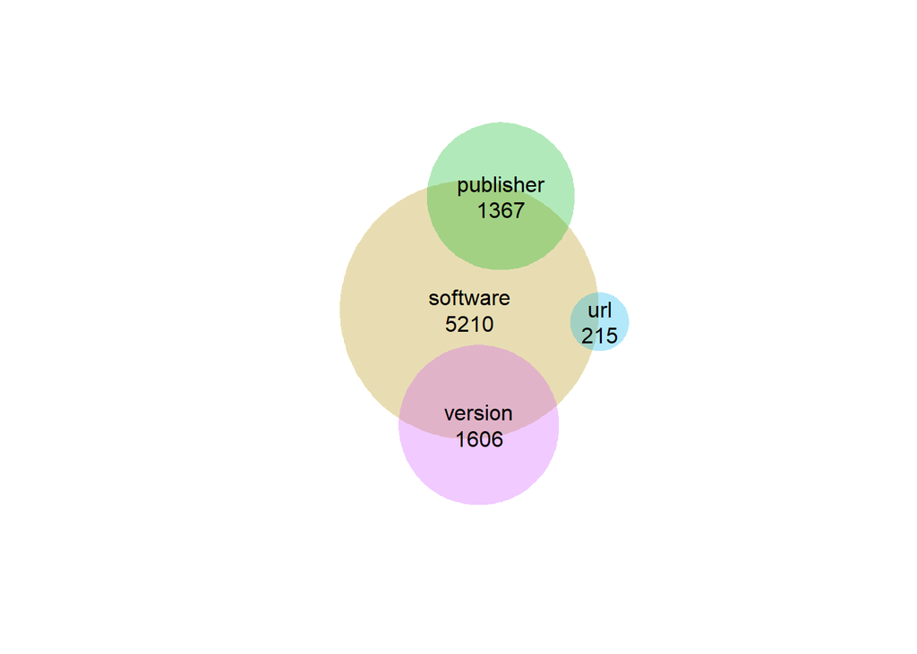

**4: How many articles were multiply annotated?**

| annotated_status | econ | pmc | Total |
| --- | --- | --- | --- |
| multiple_annotated | 6.2% (152) | 16.6% (419) | 11.5% (571) |
| single_annotated | 93.8% (2298) | 83.4% (2102) | 88.5% (4400) |
| Total | 100.0% (2450) | 100.0% (2521) | 100.0% (4971) |

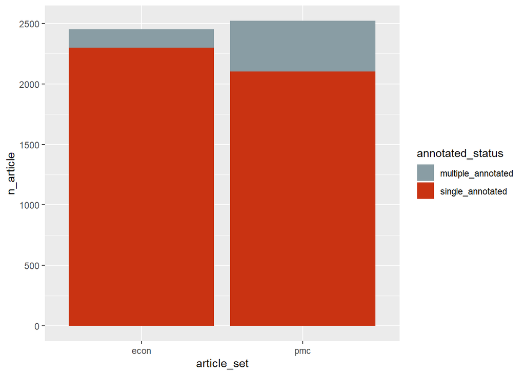

**5: The top 10 mentioned software entities**

| software | n_mention |
| --- | --- |
| SPSS | 376 |
| SAS | 103 |
| ImageJ | 83 |
| Stata | 79 |
| R | 72 |
| STATA | 53 |
| MATLAB | 50 |
| GraphPad Prism | 48 |
| Excel | 38 |
| Matlab | 34 |

**Top 10 software mentioned in PMC articles:**

| software | n_mention |
| --- | --- |
| SPSS | 370 |
| SAS | 95 |
| ImageJ | 83 |
| R | 68 |
| GraphPad Prism | 48 |
| Stata | 39 |
| MATLAB | 38 |
| Excel | 34 |
| Prism | 34 |
| STATA | 29 |

**Top 10 software mentioned in econ articles:**

| software | n_mention |
| --- | --- |
| Stata | 40 |
| Internet Explorer | 27 |
| Windows | 27 |
| Java | 25 |
| STATA | 24 |
| PubPub | 18 |
| Matlab | 16 |
| LQDG Toolbox | 13 |
| MATLAB | 12 |
| PanelWhiz | 11 |

**6. Distribution of mention counts across articles:**

**In all the articles:**

| mention_count | article_count |
| --- | --- |
| (0, 10] | 1361 |
| (10, 25] | 48 |
| (25, 50] | 8 |
| (75, 300) | 1 |
| Total | 1418 |

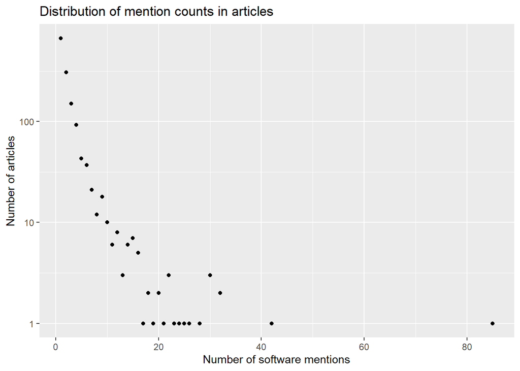

**In different article sets:**

| mention_count | econ | pmc |
| --- | --- | --- |
| (0, 10] | 149 | 1212 |
| (10, 25] | 6 | 42 |
| (25, 50] | NA | 8 |
| (75, 300) | 1 | NA |
| Total | 156 | 1262 |

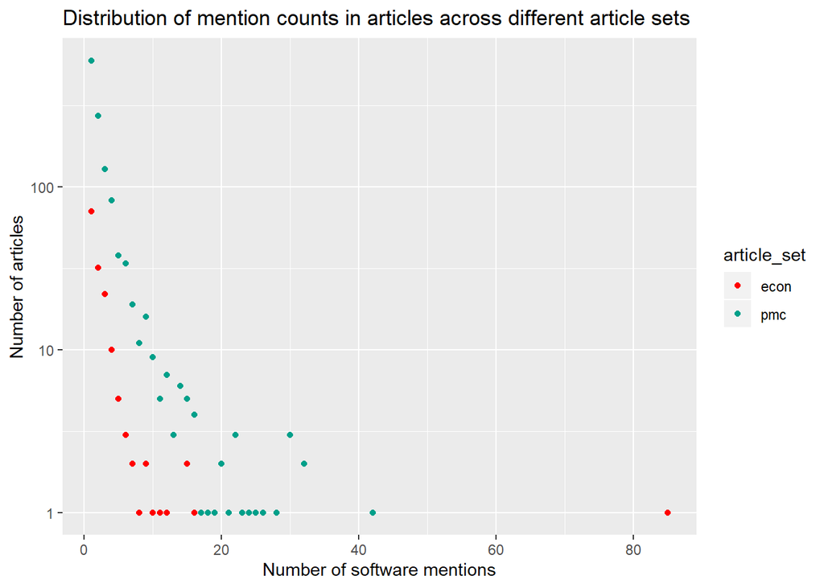